# IMDb: A Simple Data Tutorial with Movies and Fun

## Team members: Guojian Wang, Shiyu Yan, Siyuan Zhang

[figure not shown]

### Table of content

#### 1. Introduction

#### 2. Data Preparation

2.1. Data source  
2.2. Import data  
2.3. Data cleansing

#### 3. Data Analysis

3.1. Data visualization  
3.2. Regression

#### 4. More Data Tutorials in R

#### 5. Machine Learning Application

#### 6. Conclusion and Extension

## 1.Introduction

When a new movie comes out, it always attracts people to go watch it and make comments on it. The impression of people who already watch the movie would affect others who haven’t watched it. IMDB score is one of the most reflective ratings of peoples’ impression about the movie. Not only that, the IMDB score is also related to how commercially successful the movie is. By investigating the relationship between IMDB and other factors, we could use this information to help other movie makers/investors reach their desired goal.

Now, we began wondering what factors could possibly affect the IMDB score and is it possible to predict the IMDB score based on the data we collected. In order to find this out, we use detailed data to examine the possible factors that could affect the IMDB score and determine the trend and relationship between those factors and IMDB score. We hope you would find helpful our analysis about the IMDB score and if you follow our steps, you can also learn how to use R/Python to make data analysis.

**Links for project motivation:**  
https://techpolicyinstitute.org/2017/09/15/rotten-tomatoes-and-imdb-reviews-strongly-correlated-with-movie-revenues/

https://en.wikipedia.org/wiki/IMDb

## 2.Data Preparation

### 2.1. Import Libraries(In python):

**i. Pandas:** data analysis and manipulation tool

**ii. Numpy:** multi-dimensional arrays and matrices

**iii. sklearn:** library for machine learning models and algorithms

**iv. matplotlib:** data visualization

```python
import pandas as pd
import numpy as np
from plotnine import *
import statsmodels.formula.api as sm
import sklearn.ensemble
import sklearn.model_selection
import sklearn.metrics
import matplotlib.pylab as plt
from sklearn.ensemble import RandomForestClassifier
from sklearn.model_selection import train_test_split
from sklearn.metrics import accuracy_score,classification_report
import warnings
warnings.filterwarnings('ignore')
```

### 2.2. Data source

IMDB 5000 Movie Dataset from kaggle https://www.kaggle.com/carolzhangdc/imdb-5000-movie-dataset

```python
df = pd.read_csv("movie_metadata.csv")
df
```

|  | color | director_name | num_critic_for_reviews | duration | director_facebook_likes | actor_3_facebook_likes | actor_2_name | actor_1_facebook_likes | gross | genres | ... | num_user_for_reviews | language | country | content_rating | budget | title_year | actor_2_facebook_likes | imdb_score | aspect_ratio | movie_facebook_likes |
| --- | --- | --- | --- | --- | --- | --- | --- | --- | --- | --- | --- | --- | --- | --- | --- | --- | --- | --- | --- | --- | --- |
| 0 | Color | James Cameron | 723.0 | 178.0 | 0.0 | 855.0 | Joel David Moore | 1000.0 | 760505847.0 | Action\|Adventure\|Fantasy\|Sci-Fi | ... | 3054.0 | English | USA | PG-13 | 237000000.0 | 2009.0 | 936.0 | 7.9 | 1.78 | 33000 |
| 1 | Color | Gore Verbinski | 302.0 | 169.0 | 563.0 | 1000.0 | Orlando Bloom | 40000.0 | 309404152.0 | Action\|Adventure\|Fantasy | ... | 1238.0 | English | USA | PG-13 | 300000000.0 | 2007.0 | 5000.0 | 7.1 | 2.35 | 0 |
| 2 | Color | Sam Mendes | 602.0 | 148.0 | 0.0 | 161.0 | Rory Kinnear | 11000.0 | 200074175.0 | Action\|Adventure\|Thriller | ... | 994.0 | English | UK | PG-13 | 245000000.0 | 2015.0 | 393.0 | 6.8 | 2.35 | 85000 |
| 3 | Color | Christopher Nolan | 813.0 | 164.0 | 22000.0 | 23000.0 | Christian Bale | 27000.0 | 448130642.0 | Action\|Thriller | ... | 2701.0 | English | USA | PG-13 | 250000000.0 | 2012.0 | 23000.0 | 8.5 | 2.35 | 164000 |
| 4 | NaN | Doug Walker | NaN | NaN | 131.0 | NaN | Rob Walker | 131.0 | NaN | Documentary | ... | NaN | NaN | NaN | NaN | NaN | NaN | 12.0 | 7.1 | NaN | 0 |
| ... | ... | ... | ... | ... | ... | ... | ... | ... | ... | ... | ... | ... | ... | ... | ... | ... | ... | ... | ... | ... | ... |
| 5038 | Color | Scott Smith | 1.0 | 87.0 | 2.0 | 318.0 | Daphne Zuniga | 637.0 | NaN | Comedy\|Drama | ... | 6.0 | English | Canada | NaN | NaN | 2013.0 | 470.0 | 7.7 | NaN | 84 |
| 5039 | Color | NaN | 43.0 | 43.0 | NaN | 319.0 | Valorie Curry | 841.0 | NaN | Crime\|Drama\|Mystery\|Thriller | ... | 359.0 | English | USA | TV-14 | NaN | NaN | 593.0 | 7.5 | 16.00 | 32000 |
| 5040 | Color | Benjamin Roberds | 13.0 | 76.0 | 0.0 | 0.0 | Maxwell Moody | 0.0 | NaN | Drama\|Horror\|Thriller | ... | 3.0 | English | USA | NaN | 1400.0 | 2013.0 | 0.0 | 6.3 | NaN | 16 |
| 5041 | Color | Daniel Hsia | 14.0 | 100.0 | 0.0 | 489.0 | Daniel Henney | 946.0 | 10443.0 | Comedy\|Drama\|Romance | ... | 9.0 | English | USA | PG-13 | NaN | 2012.0 | 719.0 | 6.3 | 2.35 | 660 |
| 5042 | Color | Jon Gunn | 43.0 | 90.0 | 16.0 | 16.0 | Brian Herzlinger | 86.0 | 85222.0 | Documentary | ... | 84.0 | English | USA | PG | 1100.0 | 2004.0 | 23.0 | 6.6 | 1.85 | 456 |

5043 rows × 28 columns

### 2.3 Data cleaning(in python)

Before we do any data visualization or exploratory analysis, we need to first clean our dataset. We drop duplicate and NA values from our dataset. Also, for better visualization and analysis, we want our 'gross' and 'budget'to be in million.

```python
df = df.drop_duplicates()
df_cleaned = df.dropna()
df_cleaned['gross_in_mil'] = df_cleaned['gross']/1000000
df_cleaned['budget_in_mil'] = df_cleaned['budget']/1000000
```

### 3.1 Data visualization (in Python)

##### Distribution of title year

First, we want to see the distribution of release year of our data.

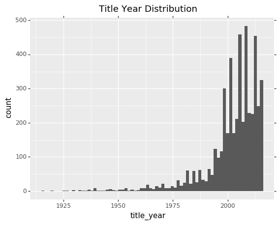

```python
ggplot(aes(x='title_year'), data=df) + geom_histogram()+labs(title = 'Title Year Distribution')
```

From the histogram of title year distribution, we can see that majority of our data were released after 1990.

##### Impact of director on IMDB scores

We want to see the impact of director on the IMDB score. We choose to use movies released after 1990 since majority of the data were released after 1990. We calculate the mean IMDB scores for each director and rank them from 1 to 806.(we choose to ignore the directors with only one movie in the dataset to remove biased data)

```python
nan = np.nan
dir_df = df.query('imdb_score != @nan & title_year >= 1990').groupby("director_name")\
.agg({'imdb_score': ['mean','count']})
dirc = dir_df['imdb_score'].query('count >1').nlargest(1000, ['mean']).reset_index()
dirc['rank'] = dirc.index+1
dirc
```

|  | director_name | mean | count | rank |
| --- | --- | --- | --- | --- |
| 0 | Christopher Nolan | 8.425000 | 8 | 1 |
| 1 | Pete Docter | 8.233333 | 3 | 2 |
| 2 | Hayao Miyazaki | 8.225000 | 4 | 3 |
| 3 | Quentin Tarantino | 8.200000 | 8 | 4 |
| 4 | Tony Kaye | 8.033333 | 3 | 5 |
| ... | ... | ... | ... | ... |
| 801 | Travis Legge | 3.250000 | 2 | 802 |
| 802 | David DeCoteau | 3.000000 | 2 | 803 |
| 803 | Craig Moss | 2.650000 | 2 | 804 |
| 804 | Jason Friedberg | 2.600000 | 4 | 805 |
| 805 | Bob Clark | 2.200000 | 2 | 806 |

806 rows × 4 columns

To obtain a better visualization, we use geom_line to connet directors' mean IMDB scores from rank 1 to rank 806.

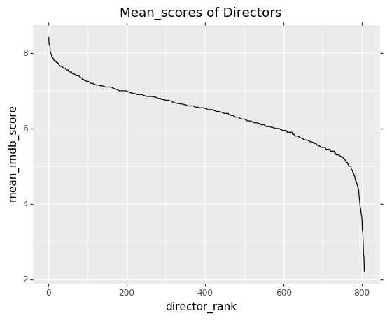

```python
ggplot(aes(x='rank', y = 'mean'), data=dirc) + geom_line()\
+ labs( x = "director_rank",y= "mean_imdb_score", title = 'Mean_scores of Directors')
```

##### Director_facebook_likes

Also, we can use director_facebook_likes to represent the popularity of directors. Then we can do a scatter plot of "director_facebook_likes vs imdb_score" to show the effect of director on the IMDB score.

```python
dfb_df = df.query('imdb_score != @nan & title_year >= 1990 & director_facebook_likes != 0\
                  & director_facebook_likes != @nan').groupby("director_name")\
.agg({'director_facebook_likes': ['mean'],'imdb_score': ['mean'], 'director_name':['count']})
dfb_df = dfb_df[dfb_df['director_name']['count']>1]
```

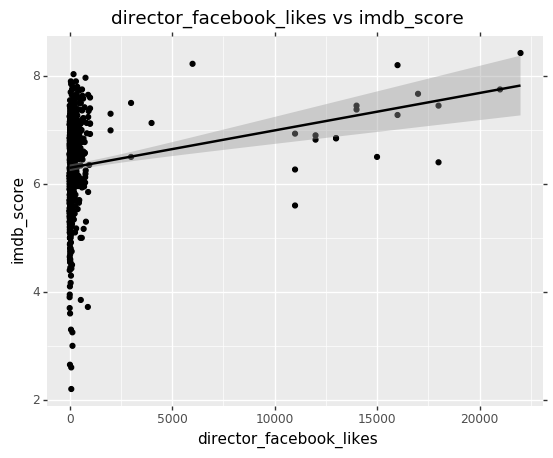

```python
(ggplot(dfb_df, aes(x='director_facebook_likes', y='imdb_score')) + geom_point()+geom_smooth(method='lm')\
 +labs( x = "director_facebook_likes",y= "imdb_score", title = 'director_facebook_likes vs imdb_score'))
```

```python
df = df.query('budget != 0 & budget != @nan') #TAKE THIS OUT WHEN COMPLIING TO HTML!!!!!!!!!!
```

### 3.2 Regression and analysis

##### Relationship between IMDB score and budget

We want to determine the relationship between budget and IMDB score. In order to obtain a more accurate result, we need to remove some extreme values. We first standardize "budget" and then use it to remove outilers(3 standard deviation away from the mean). Then we plot the filtered data to get a "IMDB score vs budget" scatter plot.

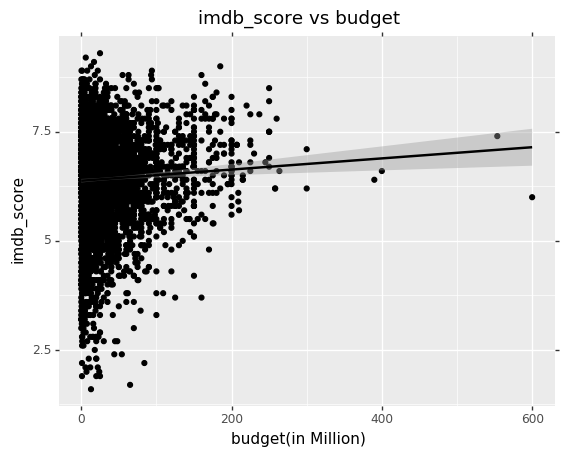

```python
stat_df = df.agg({'budget': ['mean', 'std']})
ln = len(df.index)
df['mean_bgt'] = [stat_df.budget[0]]* ln
df['std_bgt'] = [stat_df.budget[1]]* ln
df['stdzd_bgt'] = (df['budget']-df['mean_bgt'])/df['std_bgt']
temp_df = df.query('stdzd_bgt < 3 & stdzd_bgt >-3')
(ggplot(temp_df, aes(x='budget/1000000', y='imdb_score')) + geom_point()+geom_smooth(method='lm')\
 +labs( x = "budget(in Million)",y= "imdb_score", title = 'imdb_score vs budget'))
```

From the scatter plot, we can see a cluster of plots at around 0-100 million. And there is a general trend of IMDB score increasing as budget increases.

##### Linear regression analysis

Now, to obtain a more detailed result, we do a linear regression analysis on 'imdb_score~budget'.

```python
res = sm.ols('imdb_score~budget', data=temp_df).fit()
res.summary()
```

OLS Regression Results

| Dep. Variable: | imdb_score | R-squared: | 0.003 |
| --- | --- | --- | --- |
| Model: | OLS | Adj. R-squared: | 0.002 |
| Method: | Least Squares | F-statistic: | 11.34 |
| Date: | Mon, 18 May 2020 | Prob (F-statistic): | 0.000763 |
| Time: | 18:13:19 | Log-Likelihood: | -6869.7 |
| No. Observations: | 4502 | AIC: | 1.374e+04 |
| Df Residuals: | 4500 | BIC: | 1.376e+04 |
| Df Model: | 1 |  |  |
| Covariance Type: | nonrobust |  |  |

|  | coef | std err | t | P>\|t\| | [0.025 | 0.975] |
| --- | --- | --- | --- | --- | --- | --- |
| Intercept | 6.3775 | 0.021 | 303.795 | 0.000 | 6.336 | 6.419 |
| budget | 1.28e-09 | 3.8e-10 | 3.368 | 0.001 | 5.35e-10 | 2.03e-09 |

| Omnibus: | 409.333 | Durbin-Watson: | 1.895 |
| --- | --- | --- | --- |
| Prob(Omnibus): | 0.000 | Jarque-Bera (JB): | 571.635 |
| Skew: | -0.733 | Prob(JB): | 7.43e-125 |
| Kurtosis: | 3.949 | Cond. No. | 6.99e+07 |

Warnings:  
[1] Standard Errors assume that the covariance matrix of the errors is correctly specified.  
[2] The condition number is large, 6.99e+07. This might indicate that there are  
strong multicollinearity or other numerical problems.

From the result of the linear regression analysis, we can see the p-value is 0.001, which is smaller than the significance lever of 0.05. We can reject the null hypothesis of no relationship between IMDB score and budget. So at 0.05 significance level, we have sufficient evidence to prove that there is a positive relationship between budget and IMDB score. However, based on the R-squared value of 0.003, the relationship is very weak in this model. Therefore, we cannot use only budget to predict the IMDB score; we need to use more variables in order to get a better approximation.

#### Relationship between IMDB score and commercial success

After having examined the relationship between budget and IMDB score, lets see the relationship between IMDB score and how successful the movie is commercially(The gross revenue)

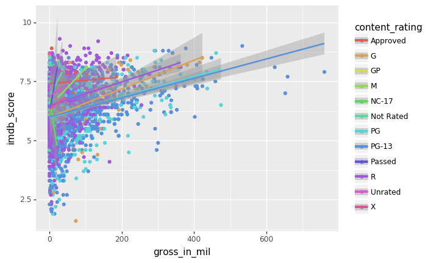

```python
res_cotent_ratingNgross = sm.ols('imdb_score ~ content_rating*gross_in_mil',\
                                 data=df_cleaned, missing = 'drop').fit(errors='coerce')

(ggplot(df_cleaned, aes(x='gross_in_mil', y='imdb_score', color='content_rating'))+ geom_point()+ geom_smooth(method='lm'))
```

We can see from the graph the overall trend that as the gross increases, the imbd score increases. The score can be somewhat influenced by the rating too.

Now lets see how the violin plot looks.

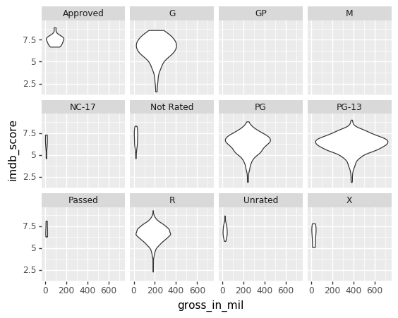

```python
(ggplot(df_cleaned, aes(x='gross_in_mil', y='imdb_score')) + geom_violin()+ facet_wrap("content_rating"))
```

We can see for most of the catagories have similar distribution. However, the gross mean can vary.

```python
res_cotent_ratingNgross.summary()
```

OLS Regression Results

| Dep. Variable: | imdb_score | R-squared: | 0.116 |
| --- | --- | --- | --- |
| Model: | OLS | Adj. R-squared: | 0.111 |
| Method: | Least Squares | F-statistic: | 22.02 |
| Date: | Mon, 18 May 2020 | Prob (F-statistic): | 8.40e-83 |
| Time: | 18:15:41 | Log-Likelihood: | -5247.7 |
| No. Observations: | 3723 | AIC: | 1.054e+04 |
| Df Residuals: | 3700 | BIC: | 1.068e+04 |
| Df Model: | 22 |  |  |
| Covariance Type: | nonrobust |  |  |

|  | coef | std err | t | P>\|t\| | [0.025 | 0.975] |
| --- | --- | --- | --- | --- | --- | --- |
| Intercept | 7.4066 | 0.333 | 22.217 | 0.000 | 6.753 | 8.060 |
| content_rating[T.G] | -1.4291 | 0.364 | -3.926 | 0.000 | -2.143 | -0.715 |
| content_rating[T.GP] | -0.0004 | 0.001 | -0.752 | 0.452 | -0.001 | 0.001 |
| content_rating[T.M] | -0.9794 | 1.352 | -0.725 | 0.469 | -3.630 | 1.671 |
| content_rating[T.NC-17] | -0.5917 | 0.583 | -1.015 | 0.310 | -1.734 | 0.551 |
| content_rating[T.Not Rated] | -0.5309 | 0.380 | -1.396 | 0.163 | -1.276 | 0.215 |
| content_rating[T.PG] | -1.4461 | 0.338 | -4.275 | 0.000 | -2.109 | -0.783 |
| content_rating[T.PG-13] | -1.4144 | 0.335 | -4.219 | 0.000 | -2.072 | -0.757 |
| content_rating[T.Passed] | -1.2588 | 1.017 | -1.238 | 0.216 | -3.252 | 0.734 |
| content_rating[T.R] | -0.9308 | 0.335 | -2.780 | 0.005 | -1.587 | -0.274 |
| content_rating[T.Unrated] | -0.5218 | 0.409 | -1.276 | 0.202 | -1.323 | 0.280 |
| content_rating[T.X] | -1.0795 | 0.637 | -1.695 | 0.090 | -2.328 | 0.169 |
| gross_in_mil | 0.0014 | 0.005 | 0.278 | 0.781 | -0.009 | 0.011 |
| content_rating[T.G]:gross_in_mil | 0.0046 | 0.005 | 0.880 | 0.379 | -0.006 | 0.015 |
| content_rating[T.GP]:gross_in_mil | -0.0175 | 0.023 | -0.752 | 0.452 | -0.063 | 0.028 |
| content_rating[T.M]:gross_in_mil | 0.0149 | 0.018 | 0.811 | 0.417 | -0.021 | 0.051 |
| content_rating[T.NC-17]:gross_in_mil | -0.1016 | 0.057 | -1.792 | 0.073 | -0.213 | 0.010 |
| content_rating[T.Not Rated]:gross_in_mil | 0.0275 | 0.022 | 1.275 | 0.202 | -0.015 | 0.070 |
| content_rating[T.PG]:gross_in_mil | 0.0030 | 0.005 | 0.575 | 0.566 | -0.007 | 0.013 |
| content_rating[T.PG-13]:gross_in_mil | 0.0027 | 0.005 | 0.520 | 0.603 | -0.007 | 0.013 |
| content_rating[T.Passed]:gross_in_mil | 0.0881 | 0.070 | 1.256 | 0.209 | -0.049 | 0.226 |
| content_rating[T.R]:gross_in_mil | 0.0036 | 0.005 | 0.697 | 0.486 | -0.007 | 0.014 |
| content_rating[T.Unrated]:gross_in_mil | 0.0086 | 0.018 | 0.474 | 0.636 | -0.027 | 0.044 |
| content_rating[T.X]:gross_in_mil | 0.0100 | 0.024 | 0.411 | 0.681 | -0.038 | 0.058 |

| Omnibus: | 298.847 | Durbin-Watson: | 1.987 |
| --- | --- | --- | --- |
| Prob(Omnibus): | 0.000 | Jarque-Bera (JB): | 426.580 |
| Skew: | -0.653 | Prob(JB): | 2.34e-93 |
| Kurtosis: | 4.022 | Cond. No. | 3.90e+17 |

Warnings:  
[1] Standard Errors assume that the covariance matrix of the errors is correctly specified.  
[2] The smallest eigenvalue is 2.63e-28. This might indicate that there are  
strong multicollinearity problems or that the design matrix is singular.

However, the r value is very small at 0.116, which means not a lot of the increase in score are due to the increase in gross.

When we look into individual catagories behavior, we can see some of the coefficient even can be negative(rating at NC-17 and GP). Thus it is not that safe to say there is a robust linear relationship between gross and score. Yet, overall, there is a weak postive relationship between gross and score.

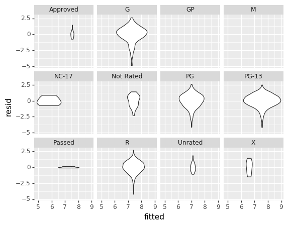

```python
df_copy = df_cleaned.copy()
df_copy['fitted'] = res_cotent_ratingNgross.fittedvalues
df_copy['resid'] = res_cotent_ratingNgross.resid
(ggplot(df_copy, aes(x='fitted', y='resid')) + geom_violin()+ facet_wrap("content_rating"))
```

As expected, the fitted model looks similar to the actual data.

### 4. More data tutorials in R

**Before we step into the machine learning part, lets use R to do some more visualization and exploratory analysis** Codes below in R will help us understand the relationship between number of voted users and the IMDB score

### Import data (In R)

[figure not shown]

### Data cleaning(in R)

The original data is messy and contains extra information that we are not interested in investigating. The original data contains 28 columns. Since we are only interested in exploring the relationships between only some of the attributes and IMDB score, we need to filter out the extra attributes we are not interested in. I also need to filter out the entities that missing the data for the attribute we interested in. After filtering the data, I only left 6 attributes 1. movie_title 2. imdb_score 3. director_name 4. num_voted_users 5. gross 6. budget Then I also removed the duplicate rows in the dataframe to ensure that the duplicated data wouldn’t affect the test results. Here is how the clean data frame would look like

[figure not shown]

### Data visualization (in R)

Before we do further data analysis about how the number of voted users would affect the IMDB score, we have a hypothesis that the higher IMDB score infers that the movie has high quality which would attract more users to see and vote for the movie. Our hypothesis is that the higher the number of voted users then the higher the IMDB score the movie would get. We plot a scatter plot of the number of voted users VS. IMDB score we also fit a trnd line using geom_smooth()

[figure not shown]

### Linear regression(in R)

Before we try to do linear regression analysis, we test the correlation between the number of voted users and the IMDB score using Pearson correlation formula

[figure not shown]

The pearson coeficient is 0.4742 which shows that there is a weak positive linear relashionship between number of voted users and the IMDB score. Now, let’s try to create a linear regression model between the number of voted users and the IMDB score

[figure not shown]

### 5. Machine Learning and predictions

```python
mdf = df.dropna().query('director_facebook_likes != 0 & actor_3_facebook_likes\
!= 0 & actor_1_facebook_likes !=0 & num_voted_users != 0 & budget != 0\
& actor_2_facebook_likes!= 0 & movie_facebook_likes != 0 & imdb_score != 0')
```

```python
mdf['actor_total_fb_likes'] = mdf['actor_1_facebook_likes'] + mdf['actor_2_facebook_likes'] + mdf['actor_3_facebook_likes']
```

```python
mdf = mdf[['budget', 'gross', 'num_voted_users', 'actor_total_fb_likes',\
           'movie_facebook_likes', 'director_facebook_likes', 'imdb_score']].reset_index().drop(columns=['index'])
```

```python
X = mdf.iloc[:,:].to_numpy()
```

```python
Y = mdf['imdb_score'].to_numpy().round().astype(int)
```

After the data is prepared, we use 70% of the data to train the random forest model, and 30% to test the model.

```python
X_train, X_test, Y_train, Y_test = train_test_split(X, Y, test_size=0.3,random_state=0)
rf = RandomForestClassifier()
rf.fit(X_train,Y_train)
predict=rf.predict(X_test)
print(accuracy_score(predict, Y_test))
```

```
0.972972972972973
```

```python
print(classification_report(Y_test, predict))
```

```
              precision    recall  f1-score   support

           2       1.00      0.33      0.50         3
           3       1.00      0.25      0.40         4
           4       0.73      0.94      0.82        17
           5       0.98      0.98      0.98        62
           6       1.00      1.00      1.00       161
           7       0.98      1.00      0.99       152
           8       0.96      0.96      0.96        79
           9       0.00      0.00      0.00         3

   micro avg       0.97      0.97      0.97       481
   macro avg       0.83      0.68      0.71       481
weighted avg       0.97      0.97      0.97       481
```

### 6. Conclusion and Extension

In this project we practiced how to use python/R to find what leads to a high IMDB score movie. according to our research, we can see that the IMDB score of a movie is influenced by multiple factors. We investigated 3 main factors, director, gross/budget and number of people voted. We found out that a good director is one of the most important factors to direct a movie with a high IMDB score. However, the gross and budget have little influence on the IMDB score. A movie with a high IMDB score would often attract more audiences to watch it and vote for it. We can see the trend that those movies that have a large number of people voted often have a higher IMDB score. Based on our research, if you are a movie lover and you are trying to find a movie you like to watch, there would be a high chance of finding a movie you prefer by looking after those movies with a high number of people who voted. You can also look after the movies directed by your favorite directors. This would help you not waste your time in looking for a movie you are interested in.

### Other Recommended Resources:

#### Links for Python/R code tutorials:

http://www.r-tutor.com/r-introduction

https://scikit-learn.org/stable/auto_examples/model_selection/plot_roc_crossval.html#sphx-glr-auto-examples-model-selection-plot-roc-crossval-py

https://towardsdatascience.com/imdb-score-prediction-401e952b5542

#### Links for IMDB score information:

https://www.quora.com/How-does-IMDbs-rating-system-work

https://help.imdb.com/article/imdb/track-movies-tv/ratings-faq/G67Y87TFYYP6TWAV#

https://www.theringer.com/tv/2019/6/12/18661850/imdb-rating-system-problems-chernobyl

### Project contribution distribution:

Shiyu Yan: Helped writing intro/conclusion. Found the relationship between IMDB score and gross/content rating. Imported R language evaluation result to jupyter notebook.

Guojian wang: Writing Introduction and conclusion. Using R code to find the relationship between IMDB and number of user voted (data visualization and linear regression)

Siyuan Zhang: Used python to do visualization of the dataset. Determined the relationship between director and IMDB score, and the relationship between budget and IMDB score. Used random forest model to predict the IMDB scores.Organized the content of the tutorial. Produced the formatted HTML file.

IMDb image source: https://theunlockr.com/android-app-of-the-day-imdb-movies-tv/

### Thank you for taking the time to read our work. Hope you have enjoyed this turorial! (◠‿◠)